# Exploratory Data Analysis of Drug Use Data

## Qu3

### (a).

In this part, we will use a K-Nearest-Neighbors model to predict use level, using the same predictors as before. The KNN algorithm is more strict with its input variables than the logistic regression algorithm. It requires that all points of the training set are equipped with a metric, so that there is a meaningful distance between the predictors of different points (and not falsely implied significance due to the varying scales of out data). For the distances to be meaningful for all the predictors, we need to scale the continuous data and find a way embed the categorical data into a metric space so that we can describe a difference between their different levels.  
For the columns of continous variables, we simply use the scale function to subtract the mean and divide by the standard deviation of the column. This is done, and then we bind the categorical variables to the front of the newly created sub-dataframe `clonedrugs`.

```r
clonedrugs <- as.data.frame(scale(druguse[,c(3,6:16)], center = TRUE, scale = TRUE))
clonedrugs <- cbind(druguse[,c(34,1,2,4,5)],clonedrugs)
```

For the catgeroical variables of the above dataset, we need to encode these into numerical values. The simplest way of doing this is for each n-ary categorical variable, project each catgeory to a unique vertex of the standard n-simplex. E.g if we have a categorical predictor ‘colour’ with values {‘red’,‘blue’,‘green’} we map each value (arbitrarly but distinctly) to $(1,0,0)^T, (0,1,0)^T, (0,0,1)^T \in \mathbb{R}^{3}$. Then the Euclidean distance of these categorical values is 0 if they’re identical and $\sqrt{2}$ otherwise. While we have to accept that this $\sqrt{2}$ value has introduced an arbitrary amount of significance, we at least a metric which gives us a constant value to imply ‘difference’ and a 0 to imply ‘same’. This is done using the model.matrix function on each column of categorical variables

```r
for (i in 2:5){
  clonedrugs[,i] <- model.matrix(~clonedrugs[,i],clonedrugs)
}
```

Next, we do a 5-fold-cross-validation and k-parameter variation in one step. This allows us to find the optimal value for k, as well as the optimum test fold. We vary k from 1 to 100 and create a $5\times 100$ matrix, where the $ij^{th}$ entry corresponds to the accuracy of KNN prediction on the $i^{th}$ fold with parameter $k = j$. The cross-fold-validation is carried out in much the same way as in Qu 2 (d). Sample creates a random order of the points and the test sample is taken as a fifth of the data points by moving through each fifth of the sample. At every point, the knn function predicts the uselevel on the training set using the test set and stores an accuracy, which is measured as the mean value of how many predictions were correct

```r
set.seed(seed = 1234)
test.size <- round(nrow(clonedrugs)/5)
inds <- sample(nrow(clonedrugs))
Accs <- matrix(0,100,5)

for (n in 1:5){
  for (k in 1:100){
    test.inds_nk <- inds[ (test.size*(n-1)+1) : (test.size*n) ]
    test.nk <- clonedrugs[test.inds_nk, ]
    train.nk <- clonedrugs[-test.inds_nk, ]

    predictions <- knn(train.nk[, -1], test.nk[, -1], train.nk$UseLevel, k = k)
    Accs[k,n] <- mean(predictions == test.nk$UseLevel)
  }
}
```

To see how each fold and k value affects the accuracy, we can make a plot of the accuracy as k varies with the fold number

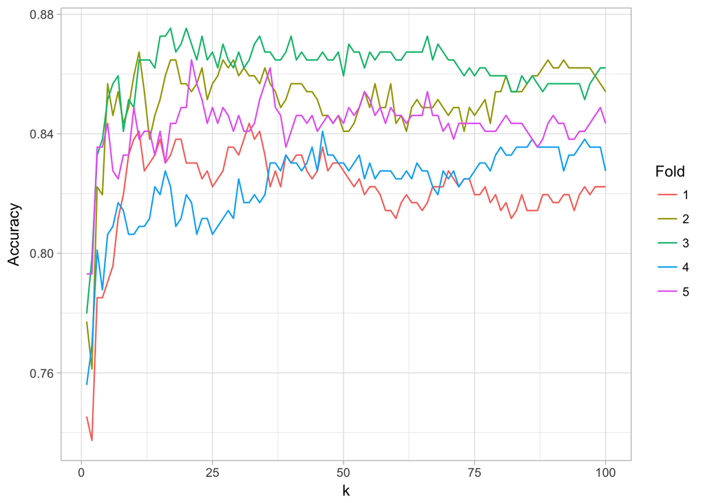

```r
moltenAccs <- melt(Accs, id.vars="")
ggplot(data=moltenAccs, aes(x=Var1, y=value, group=Var2, color=factor(Var2))) + geom_line() +
  xlab("k") + ylab('Accuracy') + scale_color_discrete(name = "Fold") +
  theme_light()
```

We can see that some folds perform better than others, but all exhibit similar general trends. For example, if k is too small the model overfits and the accuracy is fairly low. As k grows, we see the knn algorithms reaching optimum close to the region $10 < k < 20$. After this, on some folds we can see indication that eventually the model begins underfitting and the accuracy starts decreasing.  
We see that fold 3 seems to have the highest accuracy reading and looks like a well behaved knn-accuracy curve. Searching the array for the maximum value, we find that it indeed lies on the third fold and in-fact occurs twice

```r
which(Accs==max(Accs),arr.ind = TRUE)
```

```
##      row col
## [1,]  17   3
## [2,]  20   3
```

We can retain more sensitivity by picking the smaller value of k=17, visualised here

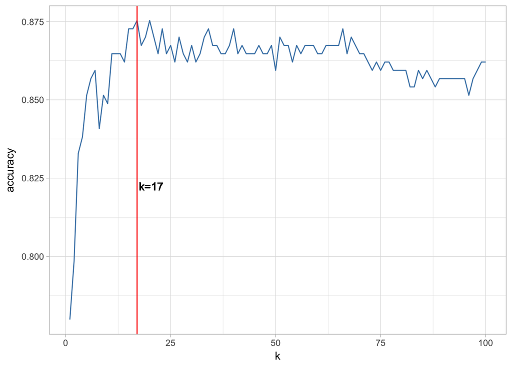

```r
ggplot(data=moltenAccs[moltenAccs$Var2==3,], aes(x = Var1, y = value)) + geom_line(color = "steelblue") +
  geom_vline(aes(xintercept = 17), color="red") + geom_text(aes(x=20,y=0.825,label="\n k=17")) +
  xlab("k") + ylab("accuracy") +
  theme_light()
```

Now that we have locked in our optimum parameters for the KNN algorithm, we can apply it to get the optimum set of predictions for the test set

```r
test.size <- round(nrow(clonedrugs)/5)

knn.test.inds <- inds[ (test.size*(3-1)+1) : (test.size*3) ]
knn.test <- clonedrugs[knn.test.inds, ]
knn.train <- clonedrugs[-knn.test.inds, ]

knn.predictions <- knn(knn.train[, -1], knn.test[, -1], knn.train$UseLevel, k = 17)
```

### (b).

This model has accuracy

```r
print(paste("Accuracy = ", format(mean(knn.predictions == knn.test$UseLevel),digits = 4)))
```

```
## [1] "Accuracy =  0.8753"
```

Slightly higher than the result we got for the logistic regression. we can visualise the accuracy in the table below

```r
x <- table(knn.predictions, knn.test$UseLevel)
kable(x)
```

|  | low | high |
| --- | --- | --- |
| low | 151 | 23 |
| high | 24 | 179 |

Since we already have the 5-fold cross analysis for k=17, we can simply find the average of the errors over the other folds to get an estimation of the extra-sample error

```r
exserr <- sum(1 - Accs[17,])/5
exserr
```

```
## [1] 0.1522546
```

## Qu4

### (a).

We will now predict if someone has ever done heroin using the first 16 predictors *and* their other drug usage.  
We begin by creating a binary response vector, which for our druguse dataset tells us whether someone has ever used heroin or not

```r
binHeroin <- ifelse(druguse$heroin == 0, "no", "yes")
```

Bind this to the predictors and drug use from the original dataset (not including the orginal `heroin` column from `druguse`) to create a new dataframe `drugforest`

```r
drugforest <- cbind(binHeroin,druguse[,c(1:23, 25:30)])
```

From here we assign the first 1500 rows of the new dataframe to training and the rest to testing. We run the random forest algorithm on this data to predict the binomial response - heroin usage. ntree is set at 500, a value for which the algorithm converges for this problem

```r
rf.train <- drugforest[1:1500,]
rf.test <- drugforest[1501:1885,]

RF <- randomForest(binHeroin ~., data=rf.train, importance = TRUE, ntree = 500)
rf.prediction <- predict(RF, rf.test)

rf.acc <- mean(rf.prediction == rf.test$binHeroin)
```

The table below shows the accuracy of the prediction

```r
x<- table(rf.prediction, rf.test$binHeroin)
kable(x)
```

|  | no | yes |
| --- | --- | --- |
| no | 317 | 27 |
| yes | 5 | 36 |

```r
print(paste("Accuracy = ", rf.acc))
```

```
## [1] "Accuracy =  0.916883116883117"
```

```r
importance(RF, 1)
```

```
##                   MeanDecreaseAccuracy
## agegroup                    7.75065730
## gender                     -1.19359353
## education                   2.05691981
## country                     8.59257428
## ethnicity                   1.66639666
## neuroticism                 3.69268145
## extraversion               -0.08547794
## opentoexperience            2.22044474
## agreeableness              -0.19077499
## conscientiousness           1.06230142
## impulsiveness               0.92963732
## sensation                   8.74458123
## caffeine                   -0.11903785
## chocolate                  -0.01561362
## nicotine                    0.92882135
## alcohol                    -1.10440634
## amphetamine                11.46270022
## amylnitrite                 3.50273271
## benzodiaz                  14.72942503
## cannabis                    5.83443233
## cocaine                    17.08577530
## crack                      24.33941152
## ecstasy                     8.96240689
## ketamine                    7.37960299
## legalhighs                  3.91056794
## LSD                        10.02417280
## methadone                  23.14837804
## mushrooms                   6.92017813
## volatiles                   5.29237395
```

### (b).

In Qu1 part (b), the second graph showed just how popular regular cannabis use is in the USA. For this reason, it seems reasonable to pose the questions: *what information do we need to know about someone to predict their propensity to use cannabis regularly?* and *Does one’s country affect the likelihood one uses cannabis regularly?* In light of the second question we don’t restrict just to the US, just in case that actaully turns out to be a big factor in predicting cannabis use.  
To predict this, we will use first 16 predictors and all other drug use data (bar cannabis use and the fictitious drug) available. The method we will use is a random forest, since this allows bagging of predictor variables and allows for complex interations with guards against overfitting. The concession we make with this of course is discretizing the numerical/continuous data.  
We begin by copying in the relevant columns of data into a new dataframe `candata`. We create a new binomial response variable which takes the value “yes” if the subject uses cannabis at least in the last month. Next we carry out the standard process to do a random forest prediction of the response variable.

```r
candata <- druguse[,c(1:19,21:30)]
candata$cannabis <- as.factor(ifelse(druguse$cannabis >3, "yes", "no"))

inds <- sample(nrow(candata))
test.size <- round(nrow(candata)/5)
ind <- inds[ (test.size*(4-1)+1) : (test.size*4) ]

can.test <- candata[ind,]
can.train <- candata[-ind,]

RFcan <- randomForest(cannabis ~. , data=can.train, importance = TRUE, ntree = 2000)
can.prediction <- predict(RFcan, can.test)
```

The accuracy for this random forest is show by the table and given numerically below

```r
kable(table(can.prediction, can.test$cannabis))
```

|  | no | yes |
| --- | --- | --- |
| no | 188 | 18 |
| yes | 43 | 128 |

```r
print(paste('Accuracy = ', mean(can.prediction == can.test$cannabis)))
```

```
## [1] "Accuracy =  0.838196286472148"
```

(see poster for plot of sample tree)

As per our first question, we inspec the Mean Decrease Accuracy of the different predictors

```r
importance(RFcan, 1)
```

```
##                   MeanDecreaseAccuracy
## agegroup                     45.211586
## gender                       20.862800
## education                    35.695791
## country                      71.739176
## ethnicity                     5.233144
## neuroticism                   7.581501
## extraversion                  1.646252
## opentoexperience             39.345808
## agreeableness                 2.770737
## conscientiousness            16.111716
## impulsiveness                14.201708
## sensation                    38.050600
## caffeine                     -1.094991
## chocolate                     2.723115
## nicotine                     46.741874
## alcohol                       5.103783
## amphetamine                  27.353606
## amylnitrite                  19.087409
## benzodiaz                     8.520224
## cocaine                      32.813780
## crack                        16.512294
## ecstasy                      51.247155
## heroin                       13.738324
## ketamine                     17.970176
## legalhighs                   57.043100
## LSD                          32.500380
## methadone                    15.491513
## mushrooms                    49.381334
## volatiles                    12.015304
```

```r
candata <- druguse[,c(1,2,4,8,12,15,21,23,26,29)]
candata$cannabis <- as.factor(ifelse(druguse$cannabis >3, "yes", "no"))

inds <- sample(nrow(candata))
test.size <- round(nrow(candata)/5)
ind <- inds[ (test.size*(4-1)+1) : (test.size*4) ]

can.test <- candata[ind,]
can.train <- candata[-ind,]

RFcan <- randomForest(cannabis ~. , data=can.train, importance = TRUE, ntree = 2000)
can.prediction <- predict(RFcan, can.test)
```

We can summarise the accuracy as above,

```r
kable(table(can.prediction, can.test$cannabis))
```

|  | no | yes |
| --- | --- | --- |
| no | 177 | 27 |
| yes | 42 | 131 |

```r
print(paste('Accuracy = ', mean(can.prediction == can.test$cannabis)))
```

```
## [1] "Accuracy =  0.816976127320955"
```

Which holds more or less the same value as in the first case. We could comfortably say we have the whittled down to the most important predictors of cannibis use in the above 10 variables, giving a confident answer to the 1st question.

```r
importance(RFcan, 1)
```

```
##                  MeanDecreaseAccuracy
## agegroup                     58.37245
## gender                       26.39574
## country                     104.30951
## opentoexperience             32.24647
## sensation                    47.30529
## nicotine                     53.36737
## cocaine                      39.95916
## ecstasy                      61.13762
## legalhighs                   58.79608
## mushrooms                    69.93532
```

And the consistency between the importance readings of the Mean Decrese Accuracy for `country` before and after thinning our predictors means we can say that the country a subject is from has a significant impact on whether they regularly partake in cannabis use, providing us an answer to our second question.

## Qu 5

Sensation is an odd one, because there isn’t an immediate intuition as to why having a high sensation value would imply anything about drug use. The logistic regression gives an estimator value of 0.72502 with a small p value of order $10^{-8}$. For this reason and the fact that it also was a significant predictor of regular cannabis use, I am compelled to call it a significant predictor of drug use.

Nicotine was predicted significant in the logistic regression for `UseLevel` and was a significant predictor of regular cannabis usage. The logistic regression gave it an estimation of around a half with a miniscule p value of order $10^{-16}$. It seems very likely that this is a significant predictor.It certainly it doesn’t seem like a unreasonable guess to say that most if someone is willing to smoke cigarettes regularly, they might well be interested in smoking cannabis for instance.

Country was shown in the last question to be a big predictor for cannabis use. Laws and cultures regularly influence attitudes to drug use, and this was definitely seen in the drastic difference betweent the UK use-levels compared to the US’s use-levels. The logistic regression gave the category `'countryUK'` an huge estimator value of -2.26286 with circumstancially irrefutable p value $10^{-05}$. Thus, I beleive it makes good sense to say country is a very significant predictor.

One thing that surprised me in the logistic regression was that there was not enough evidence to suggest `agegroup` was a significant predictor for druguse. while the category `'agegroup65+'` got a huge estimator value of -16.73692, the standard error for this was a whopping 486 which gave us the non-informative p value of 0.97. However, we have seen that agegroup was likely a very significant predictor of regular cannabis use, and the frequentist plot in qu 1 (b) showed very recognisable trends across age groups which transcended drug types. Also, it makes sense logically that age predisposes a subject to drug-use levels: we rarely imagine those 65+ to be high-use-level drug users, at least not recreationally, but we *are* well aware of drug epidemics breaking out in the youngest members of society. Going off the results in Qu 4 and Qu 1, it seems logical to call this a significant predictor for druguse, even if it cannot be backed up by the logistic regression - this is equally refutable by matter of difference of opinion.

Finally, education had a small estimator value of -0.24 in the logistic regression with convicing p value 0.012. This seems enough to call it a significant predictor, even if that significance is not very large. This also correlates with general belief that education decreases ones likelihood to abuse drugs, given better opportunities/ understanding of the dangers.

The other predictors did not show enough evidence, through large p values in the logistic regression, elimination in the prediction of regular cannabis use or otherwise, that they were significant predictors. Frequentist arguements alone, such as correlation between impulsiveness and high-use-levels are generally not enough to support the belief in the significance of the predictive power of a variable.

## Mastery

The strengths of the paper are:  
- The inclusion criteria does good work to minimise noise. “It is known that racial and ethnic minorities vary in their treatment access and success levels [25–27]. Thus, we restricted our analysis only to cases indicating a Hispanic/Latino ethnicity, 18 years old or older, and treatment in outpatient service settings.” This tailors the result to the specific subset of subjects.  
- Accounted for 2-way interactions  
- The discussion of the limitations of each model is very comprehensive  
The weaknesses of the paper are:  
- encoding of the response variable for treatment discharge status is contentious. For example, encoding ‘incarceration’ as ‘unsuccessful’ treatment introduces a bias. In fact this is equivalent to providing the negative response to an NA value. The data set is large enough for this to be cleaned out, only true failures should be categorized as such.  
- 2-fold cross-validation is the smallest cross-validation possible, so this may not give a good estimation of the extra-sample error.  
- the full implication of weighting the algorithms in SL is not discussed and ratified as sensible.

The direction I suggest heading in for interested readers/researchers is to try the SL method for a broader (in terms of personal predictors which were limited in the study) data set and compare to the algorithm again, to see where in such a case the meager improvement of SL increases, in the position where such a task would cause overfitting in ANNs and be more difficult for a logistic regression to handle. One could also try answering the question “What is the treatment success rate difference between Hispanics with comorbid psychiatric disorders and those without comorbid disorders?”, as the paper suggests.